# Automobile_data

#### Name: Suman Kumar

#### Purpose: modeling with sklearn

#### Status: Incomplete

Part / To Add inferences and description and conclusion of the analysis

# Performing regression analysis on Automobile Data to find the consumption of fuel/mileage/fuel economy of Automobile

Don't ever use Automobile Data to find the fuel economy of Tesla... (Choose your dataset wisely and Knowledge about the domain will always be helpful)

```python
import pandas as pd
import numpy as np
from sklearn.model_selection import train_test_split
from sklearn.linear_model import LinearRegression
from sklearn.metrics import r2_score as R2
import matplotlib.pyplot as plt
import seaborn as sn
import datetime as dt
```

```python
print(sk.__version__)
```

```
0.21.3
```

```python
df=pd.read_csv("B:\\Practice\\Python\\Automobile Dataset\\automobile.csv")
df.head(3)
```

|  | mpg | cylinders | displacement | horsepower | weight | acceleration | model year | origin | car name |
| --- | --- | --- | --- | --- | --- | --- | --- | --- | --- |
| 0 | 18.0 | 8 | 307.0 | 130 | 3504 | 12.0 | 70 | 1 | chevrolet chevelle malibu |
| 1 | 15.0 | 8 | 350.0 | 165 | 3693 | 11.5 | 70 | 1 | buick skylark 320 |
| 2 | 18.0 | 8 | 318.0 | 150 | 3436 | 11.0 | 70 | 1 | plymouth satellite |

```python
# pd.set_option("display.max_columns"=30)
# pd.set_option('display.max_columns', 30)
```

```python
df.sample(5)
```

|  | mpg | cylinders | displacement | horsepower | weight | acceleration | model year | origin | car name |
| --- | --- | --- | --- | --- | --- | --- | --- | --- | --- |
| 134 | 16.0 | 6 | 258.0 | 110 | 3632 | 18.0 | 74 | 1 | amc matador |
| 322 | 46.6 | 4 | 86.0 | 65 | 2110 | 17.9 | 80 | 3 | mazda glc |
| 148 | 26.0 | 4 | 116.0 | 75 | 2246 | 14.0 | 74 | 2 | fiat 124 tc |
| 362 | 24.2 | 6 | 146.0 | 120 | 2930 | 13.8 | 81 | 3 | datsun 810 maxima |
| 83 | 28.0 | 4 | 98.0 | 80 | 2164 | 15.0 | 72 | 1 | dodge colt (sw) |

```python
# help(pd.set_option)
# dir (pd.set_option)
```

```python
df.shape
df_v1=df.replace("?",np.nan)
df_v1=df_v1.dropna()
df_v1.shape
df_v1.drop(['origin','car name'],axis=1,inplace=True)
```

```python
df_v1.shape
df_v1.head(3)
```

|  | mpg | cylinders | displacement | horsepower | weight | acceleration | model year |
| --- | --- | --- | --- | --- | --- | --- | --- |
| 0 | 18.0 | 8 | 307.0 | 130 | 3504 | 12.0 | 70 |
| 1 | 15.0 | 8 | 350.0 | 165 | 3693 | 11.5 | 70 |
| 2 | 18.0 | 8 | 318.0 | 150 | 3436 | 11.0 | 70 |

```python
df_v1['model year']='19'+df_v1['model year'].astype(str)
```

```python
df_v1["age"]=dt.datetime.now().year-  pd.to_numeric(df_v1['model year'])
df_v1.drop(['model year'],axis=1,inplace=True)
df_v1.sample(3)
```

|  | mpg | cylinders | displacement | horsepower | weight | acceleration | age |
| --- | --- | --- | --- | --- | --- | --- | --- |
| 131 | 32.0 | 4 | 71.0 | 65 | 1836 | 21.0 | 46 |
| 50 | 28.0 | 4 | 116.0 | 90 | 2123 | 14.0 | 49 |
| 93 | 14.0 | 8 | 318.0 | 150 | 4237 | 14.5 | 47 |

```python
df_v1.dtypes
# All the data types need to be numeric
df_v1['horsepower']=pd.to_numeric(df_v1['horsepower'],errors='coerce')
```

```python
df_v1.describe()
```

|  | mpg | cylinders | displacement | horsepower | weight | acceleration | age |
| --- | --- | --- | --- | --- | --- | --- | --- |
| count | 392.000000 | 392.000000 | 392.000000 | 392.000000 | 392.000000 | 392.000000 | 392.000000 |
| mean | 23.445918 | 5.471939 | 194.411990 | 104.469388 | 2977.584184 | 15.541327 | 44.020408 |
| std | 7.805007 | 1.705783 | 104.644004 | 38.491160 | 849.402560 | 2.758864 | 3.683737 |
| min | 9.000000 | 3.000000 | 68.000000 | 46.000000 | 1613.000000 | 8.000000 | 38.000000 |
| 25% | 17.000000 | 4.000000 | 105.000000 | 75.000000 | 2225.250000 | 13.775000 | 41.000000 |
| 50% | 22.750000 | 4.000000 | 151.000000 | 93.500000 | 2803.500000 | 15.500000 | 44.000000 |
| 75% | 29.000000 | 8.000000 | 275.750000 | 126.000000 | 3614.750000 | 17.025000 | 47.000000 |
| max | 46.600000 | 8.000000 | 455.000000 | 230.000000 | 5140.000000 | 24.800000 | 50.000000 |

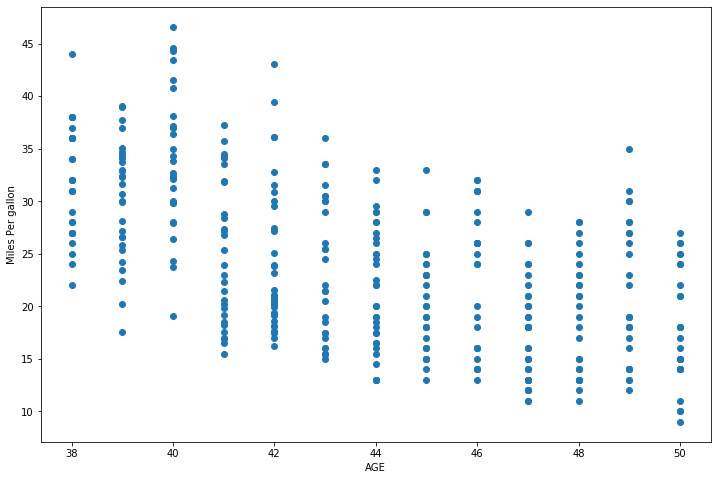

```python
fix,ax=plt.subplots(figsize=(12,8))
plt.scatter(df_v1['age'],df_v1['mpg'])
plt.xlabel('AGE')
plt.ylabel('Miles Per gallon')
```

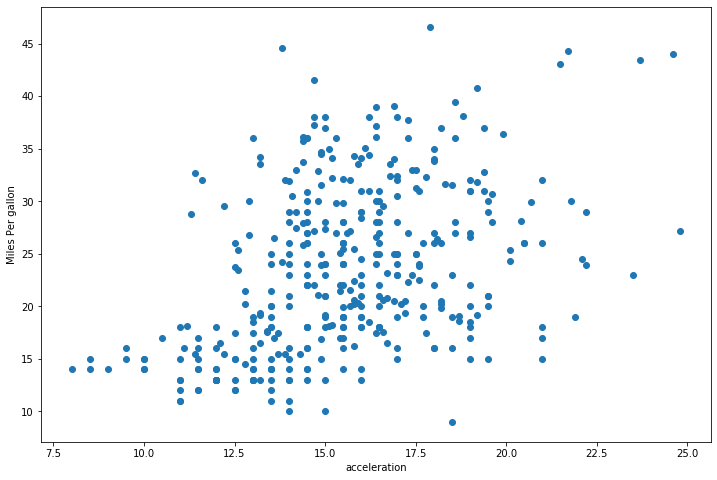

```python
fix,ax=plt.subplots(figsize=(12,8))
plt.scatter(df_v1['acceleration'],df_v1['mpg'])
plt.xlabel('acceleration')
plt.ylabel('Miles Per gallon')
```

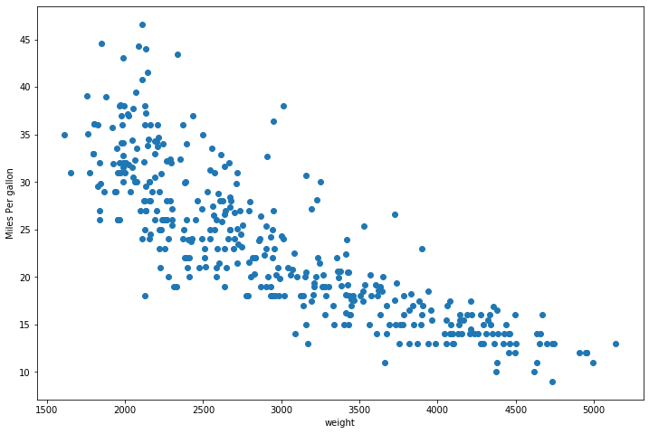

```python
fix,ax=plt.subplots(figsize=(12,8))
plt.scatter(df_v1['weight'],df_v1['mpg'])
plt.xlabel('weight')
plt.ylabel('Miles Per gallon')
```

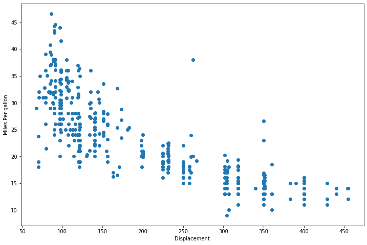

```python
fix,ax=plt.subplots(figsize=(12,8))
plt.scatter(df_v1['displacement'],df_v1['mpg'])
plt.xlabel('Displacement')
plt.ylabel('Miles Per gallon')
```

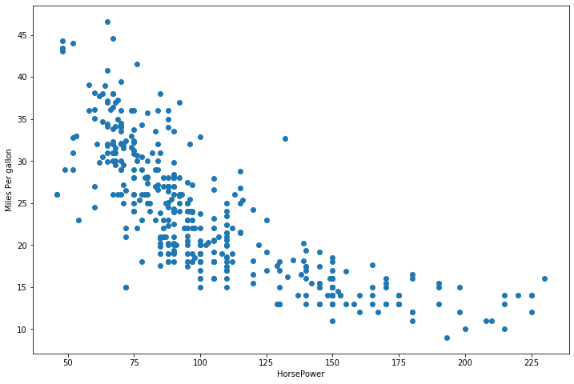

```python
fix,ax=plt.subplots(figsize=(12,8))
plt.scatter(df_v1['horsepower'],df_v1['mpg'])
plt.xlabel('HorsePower')
plt.ylabel('Miles Per gallon')
```

```python
df_corr=df_v1.corr()
df_corr
```

|  | mpg | cylinders | displacement | horsepower | weight | acceleration | age |
| --- | --- | --- | --- | --- | --- | --- | --- |
| mpg | 1.000000 | -0.777618 | -0.805127 | -0.778427 | -0.832244 | 0.423329 | -0.580541 |
| cylinders | -0.777618 | 1.000000 | 0.950823 | 0.842983 | 0.897527 | -0.504683 | 0.345647 |
| displacement | -0.805127 | 0.950823 | 1.000000 | 0.897257 | 0.932994 | -0.543800 | 0.369855 |
| horsepower | -0.778427 | 0.842983 | 0.897257 | 1.000000 | 0.864538 | -0.689196 | 0.416361 |
| weight | -0.832244 | 0.897527 | 0.932994 | 0.864538 | 1.000000 | -0.416839 | 0.309120 |
| acceleration | 0.423329 | -0.504683 | -0.543800 | -0.689196 | -0.416839 | 1.000000 | -0.290316 |
| age | -0.580541 | 0.345647 | 0.369855 | 0.416361 | 0.309120 | -0.290316 | 1.000000 |

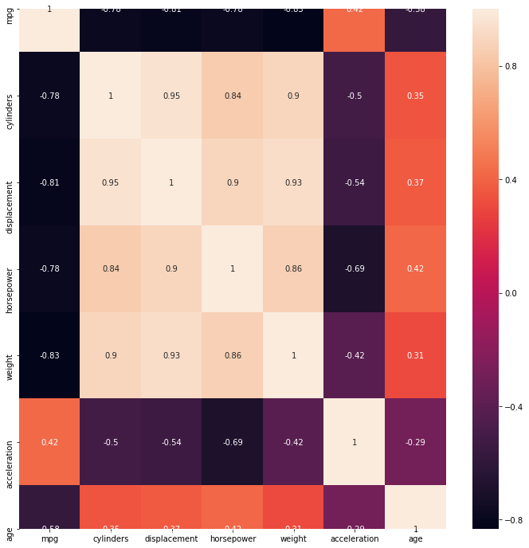

```python
fig,ax=plt.subplots(figsize=(12,12))
sn.heatmap(df_corr,annot=True)
```

```python
#shuffling and reindexing
df_v1=df_v1.sample(frac=1).reset_index(drop=True)
```

```python
df_v1.to_csv('B:\\Practice\\Python\\Automobile Dataset\\automobile_processed.csv',index=False)
```

```python
###no####no

#!ls datasets
```

[output not shown]

#### Learnings till now:

We have simply obtained the data, cleaned the data and tried to see the relation of data with the mileage (mpg)

However we have not check the colinearity of variable with each other. Sometimes it may be possible to identify repeating data which complicates the model. Such variable can be identified and be removed Standardizing variable dimensionality reduction has not yet be performed.

```python
data=pd.read_csv("B:\\Practice\\Python\\Automobile Dataset\\automobile_processed.csv")
data.sample(3)
```

|  | mpg | cylinders | displacement | horsepower | weight | acceleration | age |
| --- | --- | --- | --- | --- | --- | --- | --- |
| 328 | 25.0 | 4 | 104.0 | 95 | 2375 | 17.5 | 50 |
| 197 | 23.0 | 4 | 140.0 | 83 | 2639 | 17.0 | 45 |
| 367 | 21.1 | 4 | 134.0 | 95 | 2515 | 14.8 | 42 |

```python
X=data[['horsepower']]
Y=data['mpg']
x_train,x_test,y_train,y_test=train_test_split(X,Y,test_size=0.3)
linear_model_auto=LinearRegression(normalize=True).fit(x_train,y_train)
print("Training Score : ", linear_model_auto.score(x_train,y_train))
y_pred=linear_model_auto.predict(x_test)
print("Testing Score :", R2(y_test,y_pred))
```

```
Training Score :  0.6181172125918766
Testing Score : 0.5390001007861545
```

#### Everytime the code is executed the score changes because it is everytime there is different sample ...although if this change is significant this shows the dearth data and hence it's not robust.

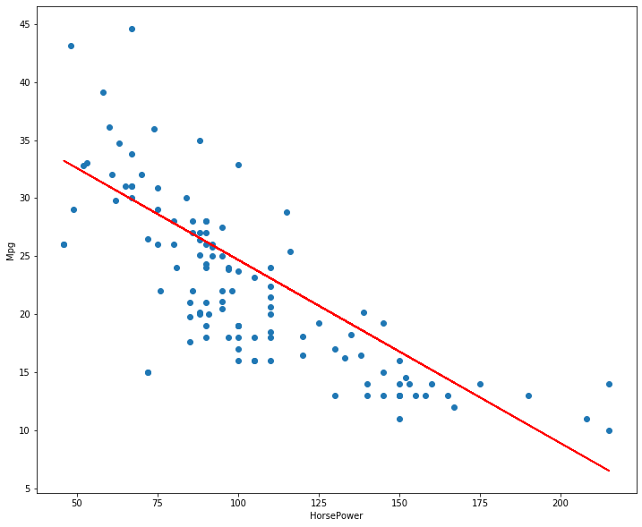

```python
fig,ax=plt.subplots(figsize=(12,10))
x_test.shape
y_test.shape
plt.scatter(x_test,y_test)
plt.plot(x_test,y_pred,color='r')

plt.xlabel('HorsePower')
plt.ylabel('Mpg')
plt.show()
```

#### Form the above date we see the negative correlation between Horsepower and mpg

```python
X=data[['age']]
Y=data['mpg']
x_train,x_test,y_train,y_test=train_test_split(X,Y,test_size=0.3)
linear_model_auto=LinearRegression(normalize=True).fit(x_train,y_train)
print("Training Score : ", linear_model_auto.score(x_train,y_train))
y_pred=linear_model_auto.predict(x_test)
print("Testing Score :", R2(y_test,y_pred))
```

```
Training Score :  0.31701109316351006
Testing Score : 0.36479727587784117
```

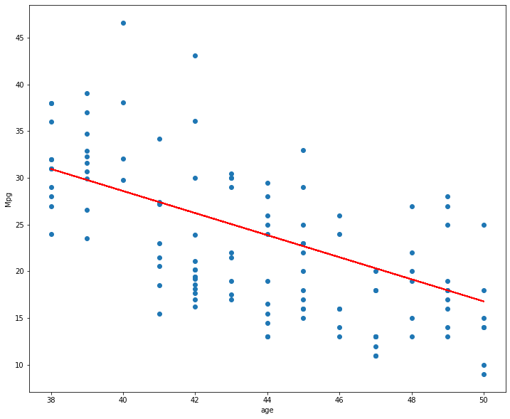

```python
fig,ax=plt.subplots(figsize=(12,10))
plt.scatter(x_test,y_test)
plt.plot(x_test,y_pred,color='r')

plt.xlabel('age')
plt.ylabel('Mpg')
plt.show()
```

#### Trying with 3 Variables

```python
X=data[['horsepower','age','displacement']]
Y=data['mpg']
x_train,x_test,y_train,y_test=train_test_split(X,Y,test_size=0.3)
linear_model_auto=LinearRegression(normalize=True).fit(x_train,y_train)
print("Training Score : ", linear_model_auto.score(x_train,y_train))
y_pred=linear_model_auto.predict(x_test)
print("Testing Score :", R2(y_test,y_pred))
```

```
Training Score :  0.7304499581216153
Testing Score : 0.7797277530864037
```

```python
predictors=x_train.columns
coef=pd.Series(linear_model_auto.coef_, predictors).sort_values() #'coef_' is an attribute
coef
```

```
age            -0.648878
displacement   -0.040234
horsepower     -0.034128
dtype: float64
```

#### Trying with 5 Variables

```python
X=data[['horsepower','displacement','weight','acceleration','cylinders']]
Y=data['mpg']
x_train,x_test,y_train,y_test=train_test_split(X,Y,test_size=0.3)
linear_model_auto=LinearRegression(normalize=True).fit(x_train,y_train)
print("Training Score : ", linear_model_auto.score(x_train,y_train))
y_pred=linear_model_auto.predict(x_test)
print("Testing Score :", R2(y_test,y_pred))
```

```
Training Score :  0.7028956730032909
Testing Score : 0.7117531610379202
```

```python
predictors=x_train.columns
coef=pd.Series(linear_model_auto.coef_, predictors).sort_values() #'coef_' is an attribute
coef
```

[output not shown]

#### Trying with all the Variables

```python
X=data[['horsepower','age','displacement','weight','acceleration','cylinders']]
Y=data['mpg']
x_train,x_test,y_train,y_test=train_test_split(X,Y,test_size=0.3)
linear_model_auto=LinearRegression(normalize=True).fit(x_train,y_train)
print("Training Score : ", linear_model_auto.score(x_train,y_train))
y_pred=linear_model_auto.predict(x_test)
print("Testing Score :", R2(y_test,y_pred))
```

```
Training Score :  0.8058876997590015
Testing Score : 0.8079567540514437
```

```python
predictors=x_train.columns
coef=pd.Series(linear_model_auto.coef_, predictors).sort_values() #'coef_' is an attribute
coef
```

```
age            -0.750243
cylinders      -0.391451
weight         -0.006504
horsepower      0.003203
displacement    0.006324
acceleration    0.073879
dtype: float64
```

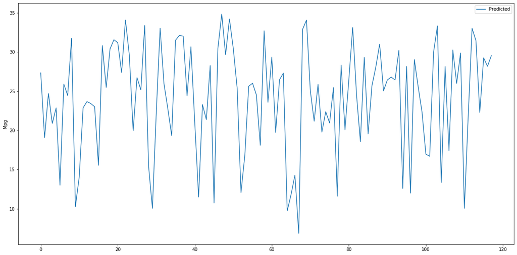

```python
plt.figure(figsize=(20,10))

plt.plot(y_pred, label="Predicted")
# plt.plot(y_test, label="Actual")

plt.ylabel('Mpg')
plt.legend()
plt.show()
```

### Trying to show kitchen sink regression does not work everytime...In this case, and these set of tools it is working well.